# Problem 1

```python
import matplotlib
import matplotlib.pyplot as plt
import numpy as np
import pandas as pd
from scipy import stats
```

assume in 1 day the average cosmic-ray background is some number 2 and the average number of gamma-rays emitted by my hypothetical source is 5

```python
X = 2
Y = 5
```

```
<BarContainer object of 11 artists>
```

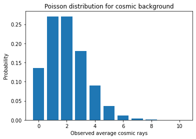

```python
dist = stats.poisson(X)
x = np.arange(0, 11)
pmf = dist.pmf(x)
plt.title("Poisson distribution for cosmic background")
plt.xlabel("Observed average cosmic rays")
plt.ylabel("Probability")
plt.bar(x, pmf, linewidth = 5)
```

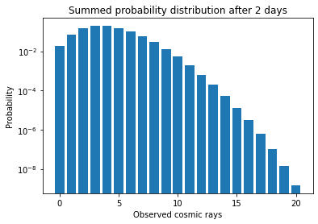

```python
sum_p = np.convolve(pmf, pmf)
plt.title("Summed probability distribution after 2 days")
plt.xlabel("Observed cosmic rays")
plt.ylabel("Probability")
plt.bar(range(len(sum_p)), sum_p, linewidth = 5)
plt.yscale('log')
```

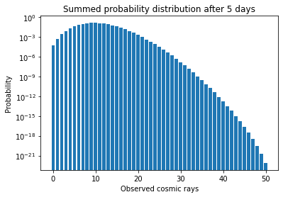

```python
pmf2 = pmf
for j in range(1, 5):
    pmf2 = np.convolve(pmf2, pmf)
plt.bar(range(len(pmf2)), pmf2, linewidth = 5)
plt.title("Summed probability distribution after 5 days")
plt.xlabel("Observed cosmic rays")
plt.ylabel("Probability")
plt.yscale('log')
```

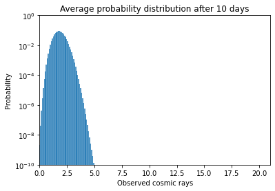

```python
# The average part c
pmf = dist.pmf(x)
pmf3 = pmf
for i in range(1, 10):
    pmf3 = np.convolve(pmf3, pmf)
plt.vlines(np.arange(len(pmf3)) / 11, 0, pmf3)
plt.title("Average probability distribution after 10 days")
plt.xlabel("Observed cosmic rays")
plt.ylabel("Probability")
plt.yscale('log')
plt.xlim(0, 21)
plt.ylim(1e-10, 1);
```

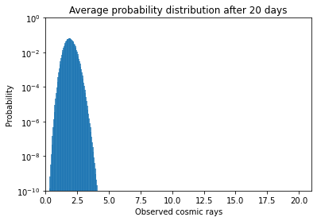

```python
# What will the graph looks like after 50 days?
pmf = dist.pmf(x)
pmf3 = pmf
for i in range(1, 20):
    pmf3 = np.convolve(pmf3, pmf)
plt.vlines(np.arange(len(pmf3)) / 21, 0, pmf3)
plt.title("Average probability distribution after 20 days")
plt.xlabel("Observed cosmic rays")
plt.ylabel("Probability")
plt.yscale('log')
plt.xlim(0, 21)
plt.ylim(1e-10, 1);
```

[figure not shown]

```python
# What will the graph looks like after 100 days?
pmf = dist.pmf(x)
pmf3 = pmf
for i in range(1, 30):
    pmf3 = np.convolve(pmf3, pmf)
plt.vlines(np.arange(len(pmf3)) / 31, 0, pmf3)
plt.title("Average probability distribution after 30 days")
plt.xlabel("Observed cosmic rays")
plt.ylabel("Probability")
plt.yscale('log')
plt.xlim(0, 1)
plt.ylim(1e-10, 1);
```

the distribution shrinks and getting closer and closer around its mean, because more values of observing cosmic rays, so it looks more Gaussian and the parabolic shape on a log scale is proves that it looks like Gaussian. for d), I pick n = 10 Summed mean 10 * 2 = 20 I'm using the poisson.sf command, it means 1 - CDF, to 5*10 = 50, but not including 50

```python
p = stats.poisson(20).sf(50 - 1)
p
```

```
1.2458926079719434e-08
```

```python
sigma = stats.norm.ppf(1 - p)
sigma
```

```
5.573844254309058
```

So it's about 5.6 sigmas,

# Problem 2

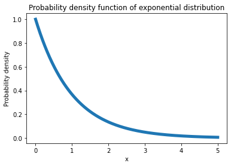

```python
dist = stats.expon(scale = 1)
x = np.linspace(0, 5, 1000)
plt.plot(x, dist.pdf(x), linewidth = 5)
plt.title("Probability density function of exponential distribution")
plt.ylabel("Probability density")
plt.xlabel("x")
```

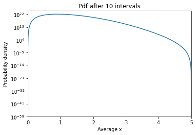

```python
pdf = dist.pdf(x)
new_pdf = pdf
for i in range(10):
    new_pdf = np.convolve(new_pdf, pdf)
plt.plot(np.linspace(0, 5, len(new_pdf)), new_pdf)
plt.title("Pdf after 10 intervals")
plt.xlabel("Average x")
plt.ylabel("Probability density")
plt.yscale('log')
plt.xlim(0, 5)
plt.ylim(1e-50, None);
```

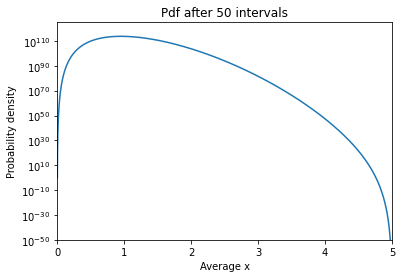

```python
pdf = dist.pdf(x)
new_pdf = pdf
for i in range(50):
    new_pdf = np.convolve(new_pdf, pdf)
plt.plot(np.linspace(0, 5, len(new_pdf)), new_pdf)
plt.title("Pdf after 50 intervals")
plt.xlabel("Average x")
plt.ylabel("Probability density")
plt.yscale('log')
plt.xlim(0, 5)
plt.ylim(1e-50, None);
```

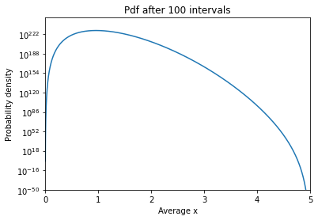

```python
pdf = dist.pdf(x)
new_pdf = pdf
for i in range(100):
    new_pdf = np.convolve(new_pdf, pdf)
plt.plot(np.linspace(0, 5, len(new_pdf)), new_pdf)
plt.title("Pdf after 100 intervals")
plt.xlabel("Average x")
plt.ylabel("Probability density")
plt.yscale('log')
plt.xlim(0, 5)
plt.ylim(1e-50, None);
```

It looks like it's getting more parabolic on a log scale with greater intervals, which means it's getting more and more Gaussian distribution like.

## Problem 3 Version 1

From looking at all the other pixels in your image, you can measure the width of the background Gaussian distribution X (pick something). Assuming you see a signal of strength Y (pick a floating-point number; optical CCDs are not sensitive enough to count photons so the readings are floating point brightnesses, not integer photons). Calculate the significance of your detection. Can you claim a discovery (traditionally 5-sigma or more)?

```
(0.0, 30.0)
```

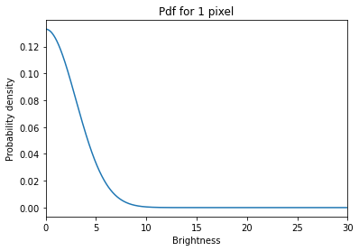

```python
dist = stats.norm(scale = 3)
x = np.linspace(0, 30, 1000)
plt.plot(x, dist.pdf(x))
plt.title("Pdf for 1 pixel")
plt.xlabel("Brightness")
plt.ylabel("Probability density")
plt.xlim(0, 30)
```

Assume I see a signal of strength 15.7

```python
p = dist.sf(15.7)
p
```

```
8.324005993862168e-08
```

```python
stats.norm.ppf(1 - p)
```

```
5.233333333294829
```

it's greater than 5 sigmas, so we claim a discovery

## Version 2

You have an alert from LIGO, but no associated detection from SWIFT. This could be because it is a black hole-black hole merger, a black hole-neutron star merger (neither seem to emit X-rays or UV light), or it could because SWIFT was indisposed at the time (wrong side of the earth in its orbit). Whatever the cause, you know what region of the sky to look in, but not which pixel.

```
(0.0, 30.0)
```

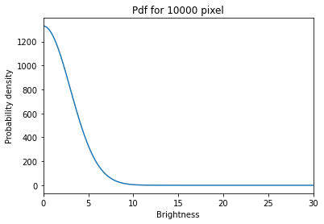

```python
dist = stats.norm(scale = 3)
x = np.linspace(0, 30, 1000)
plt.plot(x, 10000* dist.pdf(x))
plt.title("Pdf for 10000 pixel")
plt.xlabel("Brightness")
plt.ylabel("Probability density")
plt.xlim(0, 30)
```

the y values of the Pdf increased

```python
p = 10000 * dist.sf(15.7)
stats.norm.ppf(1 - p)
```

```
3.144307995540609
```

It's less than 5 sigmas, wo we can't say reject the null

# Problem 4

```python
# A
p1 = stats.norm.sf(5)
p1
```

```
2.866515718791933e-07
```

```python
v1 = dist.ppf(1 - p1)
v1
```

```
14.999999999910528
```

```python
# B
p2 = p1 / 10000
v2 = dist.ppf(1 - p2)
v2
```

```
19.651612460674965
```

```python
#C
(v2 - v1)/ v1
```

```
0.31010749738614546
```

So it should be 31% brighter with 10000 pixels. the penalty is low because the large decrease in probability slightly increased threshold, when the trials factor increase, the threshold increase logarithmically.

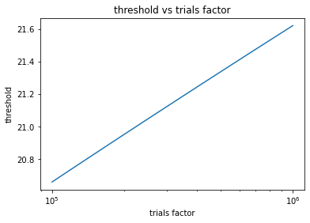

```python
# D
n = np.linspace(100000, 1000000)
p3 = p1 / n
th = dist.ppf(1 - p3)
plt.plot(n, th)
plt.title('threshold vs trials factor')
plt.xlabel('trials factor')
plt.ylabel('threshold');
plt.xscale('log')
```

signal threshold increases when the trials factor increases logarithmically.

# Extra credit

```
(0.0, 30.0)
```

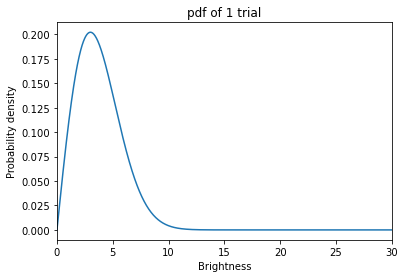

```python
dist = stats.rayleigh(scale = 3)
x = np.linspace(0, 30, 1000)
plt.title("pdf of 1 trial")
plt.xlabel("Brightness")
plt.ylabel("Probability density")
plt.plot(x, dist.pdf(x))
plt.xlim(0, 30)
```

```python
t1 = dist.ppf(1 - p1)
t2 = dist.ppf(1 - p1/ 10000)
(t2 - t1)/ t1
```

```
0.2693988403836943
```

threshold increase about 27%, for rayleigh distributed, penalty is smaller with a big trial factor.